# *Executive Summary*: Statistik Industri Agro

Aulia Dini Rafsanjani

2026-03-11

### Pendahuluan

Agroindustri (Agro) didefiniskan industri yang memanfaatkan hasil pertanian sebagai bahan baku atau produk yang digunakan dalam usaha pertanian. Industri ini disiapkan untuk mengolah komoditas pertanian primer, baik tanaman maupun hewan, menjadi produk olahan, baik produk antara maupun produk akhir. Agro dianggap sebagai tulang punggung ekonomi Indonesia karena menyumbang >52% PDB industri non-migas, menyerap >4 juta tenaga kerja, dan menargetkan ekspor tinggi (misal:sawit dan karet) melalui hilirisasi berkelanjutan.

Saat ini, agroindustri menjadi fokus utama pemerintah semenjak kebijakan hilirisasi diterapkan. Tujuan dari kebijakan hilirisasi adalah adanya peningkatan nilai tambah dari produk pertanian. Dari 28 komoditas hilirisasi, terdapat 14 komoditas yang menjadi bagian dari Agroindustri, yaitu : sawit, kelapa, karet, biofuel, kayu balok, getah pinus, udang, ikan TCT, rajungan, rumput laut, garam, kakao, pala, tilapia.

Dokumen ini disusun untuk menyediakan *executive summary* tentang industri agro, meliputi data jumlah perusahaan, tenaga kerja, output dan strukturnya, input dan strukturnya, beserta isu terkait yang sedang berkembang tentang industri agro. Melalui executive summary ini, diharapkan para pemangku kebijakan dapat memperoleh informasi yang komprehensif sehingga kebijakan yang disusun adalah kebijakan berbasis data *(evidence-based policy)*.

### *Disclaimer*

- Industri Agro mencakup kategori C (Industri Pengolahan) golongan pokok 13 Klasifikasi Baku Lapangan Usaha Indonesia (KBLI) yaitu : Industri Agro meliputi beberapa kode Klasifikasi Baku Lapangan Usaha Indonesia (KBLI), yaitu : 10-Industri Makanan, 11- Industri Minuman, 12- Industri Pengolahan Tembakau, 16-Industri Kayu, Barang dari Kayu dan Gabus (Tidak Termasuk Furnitur) dan Barang Anyaman dari Bambu, Rotan dan Sejenisnya, 17-Industri Kertas dan Barang dari Kertas, 22-Industri Karet, Barang dari Karet dan Plastik, 31-Industri *Furniture*.
- Sumber data yang digunakan merupakan gabungan dari hasil Updating Direktori (DPA) dan Survei Tahunan Perusahaan Industri Manufaktur (STPIM) yang dilakukan setiap tahun. Pada tahun 2016, STPIM terintegrasi dengan Sensus Ekonomi 2016. Target responden survei adalah perusahaan berskala besar dan menengah.
- Klasifikasi skala usaha didasarkan pada tenaga kerja hingga tahun 2020. Setelahnya, klasifikasi skala usaha sejak tahun 2021 menjadi: Industri besar adalah perusahaan industri manufaktur yang memenuhi salah satu kriteria jumlah tenaga kerja lebih dari 99 orang atau nilai akumulasi investasi/modal tetap sejak pendirian pabrik lebih dari Rp. 10 miliar atau omset perusahaan lebih besar dari Rp. 50 miliar; Industri menengah adalah perusahaan industri manufaktur yang memenuhi salah satu kriteria jumlah tenaga kerja kurang dari sama dengan 99 orang atau nilai akumulasi investasi/modal tetap sejak pendirian pabrik Rp. 5-10 miliar atau omset perusahaan Rp. 10-50 miliar.
- Publikasi lengkap dapat dilihat di www.bps.go.id

### Jumlah Perusahaan

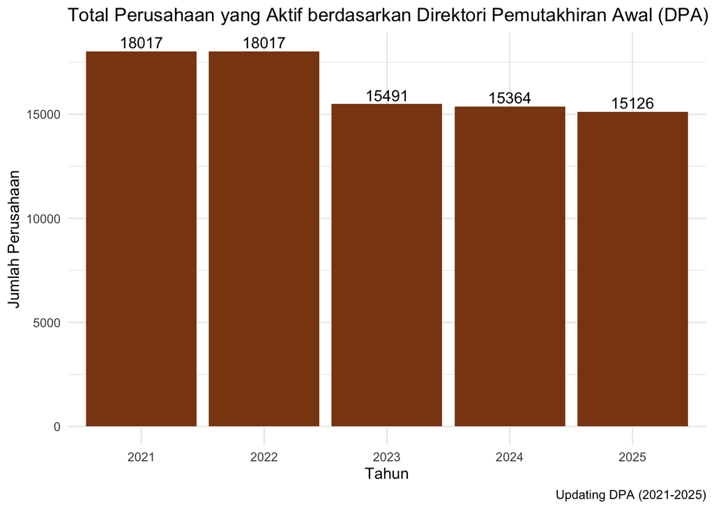

### Sebaran Industri Agro tahun 2025

Jumlah industri agro tahun 2025 tertinggi berlokasi di Jawa Timur dengan jumlah 3214 dan terendah berada di Papua Pegunungan dengan jumlah 6. Secara umum, lokasi industri Agro dominan secara jumlah berada di pulau Jawa.

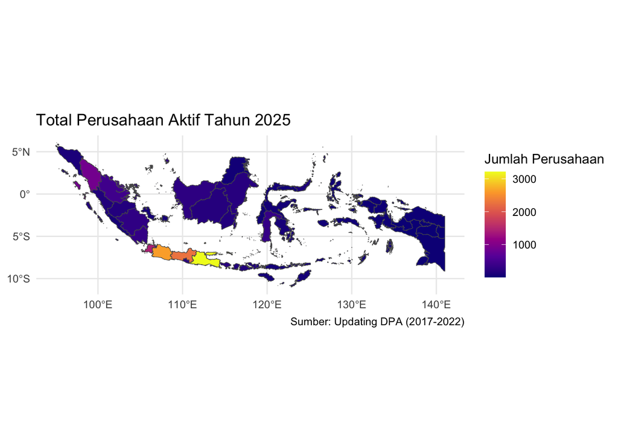

### Tenaga Kerja

Jumlah tenaga kerja di industri agro secara umum mengalami penurunan selama tahun 2017 hingga tahun 2022. Pada tahun 2017, industri agro menyerap 2,6 juta tenaga kerja. Namun, pada tahun 2022, penyerapan tenaga kerja industri agro sebesar 2,3 juta. Penurunan sebesar 12 persen terjadi selama periode 2017-2022.

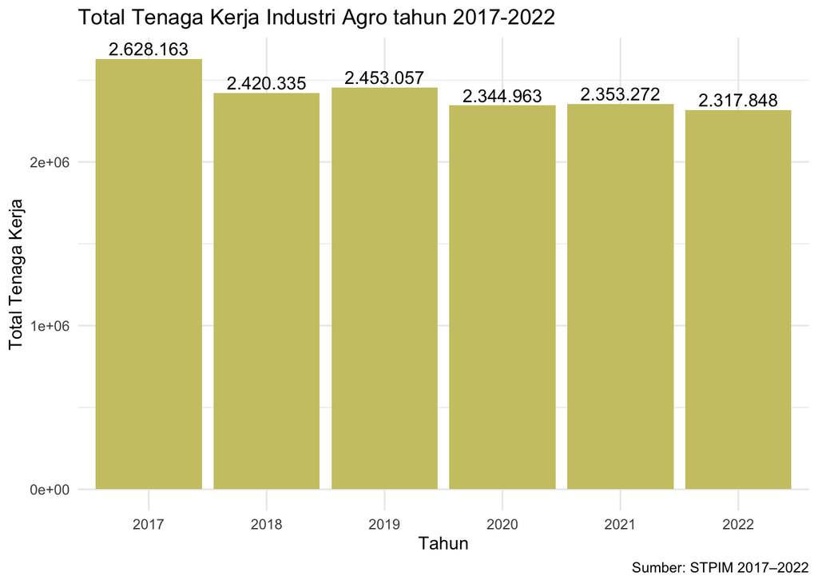

### Output

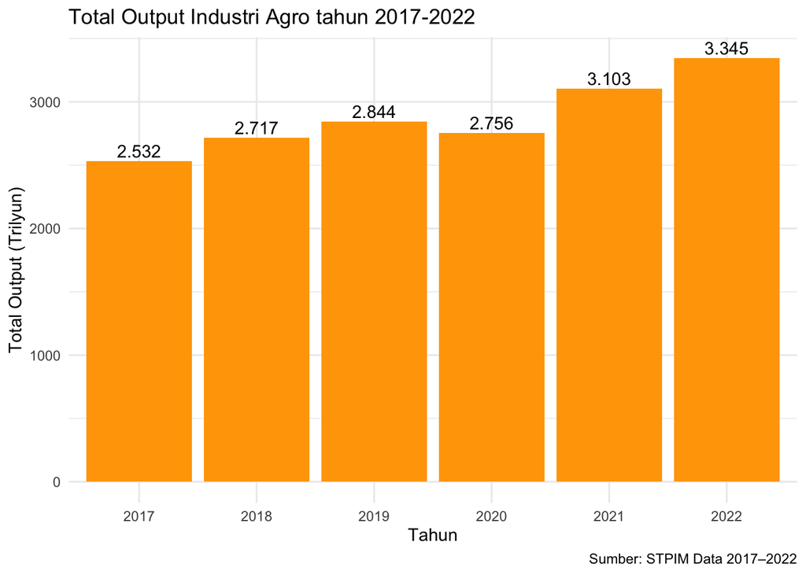

### Struktur Output

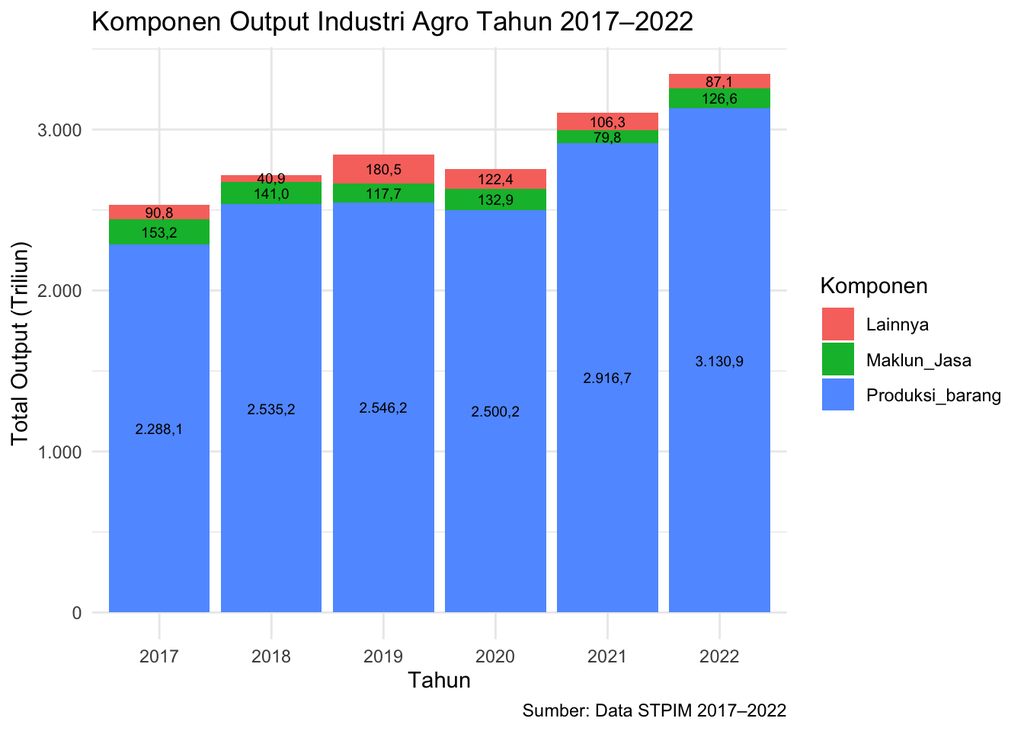

### Input

Total pengeluaran untuk input produksi industri agro cenderung mengalami kenaikan selama periode tahun 2017 hingga tahun 2022. Total pengeluaran input industri agro tertinggi terjadi pada tahun 2022, dimana nilainya mencapai 2.178 Trilyun Rupiah. Pada masa Covid-19 yaitu tahun 2019-2020, total input industri agro mengalami penurunan tipis sebesar 0,22 persen. Secara umum, nilai input pasca pandemi lebih tinggi dibandingkan sebelum pandemi terjadi.

*Catatan*: Input meliputi pengeluaran upah untuk tenaga kerja, bahan baku lokal dan impor, serta pengeluaran untuk input lainnya yang dikeluarkan oleh perusahaan.

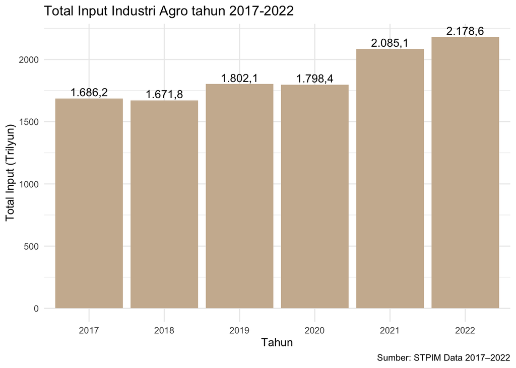

### Struktur Input

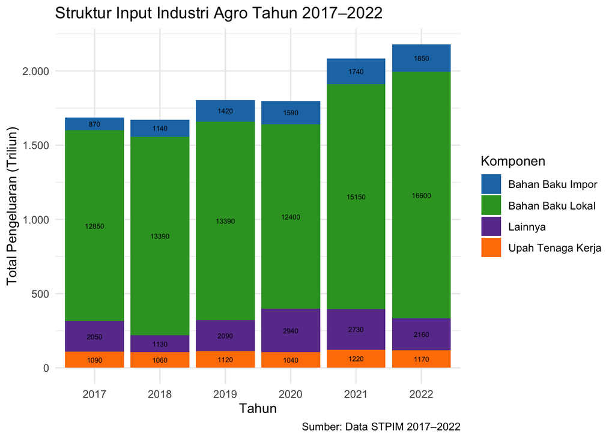

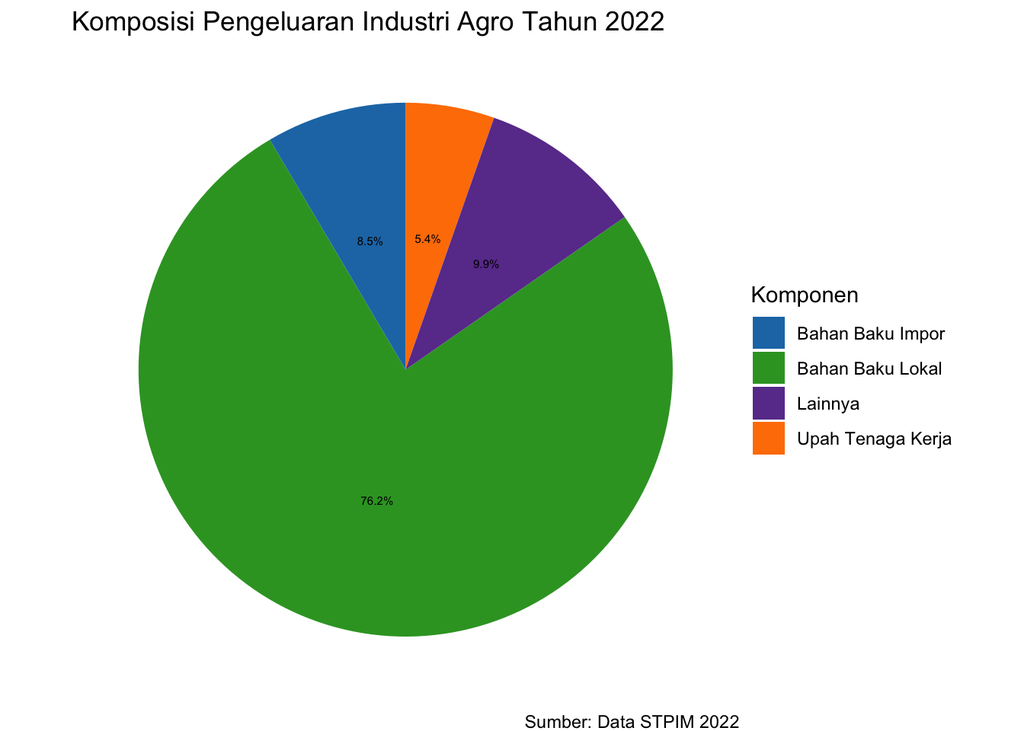

### Isu Peningkatan Nilai Tambah pada Industri Agro

Secara umum, nilai tambah industri agro menunjukkan tren meningkat dalam jangka menengah. Pada tahun 2017 nilainya sebesar 2.087,8 triliun rupiah dan meningkat menjadi 2.755,6 triliun rupiah pada tahun 2022. Artinya, selama periode tersebut terjadi peningkatan sekitar 667,8 triliun rupiah atau sekitar 32 persen. Hal ini menunjukkan bahwa sektor industri agro tetap menjadi salah satu sektor yang berperan penting dalam penciptaan nilai tambah di industri pengolahan. Meskipun tren keseluruhan meningkat, terdapat penurunan pada tahun 2020, yaitu dari 2.433,3 triliun rupiah pada tahun 2019 menjadi 2.269,3 triliun rupiah pada tahun 2020. Setelah penurunan pada tahun 2020, nilai tambah industri agro kembali mengalami pemulihan yang cukup kuat.

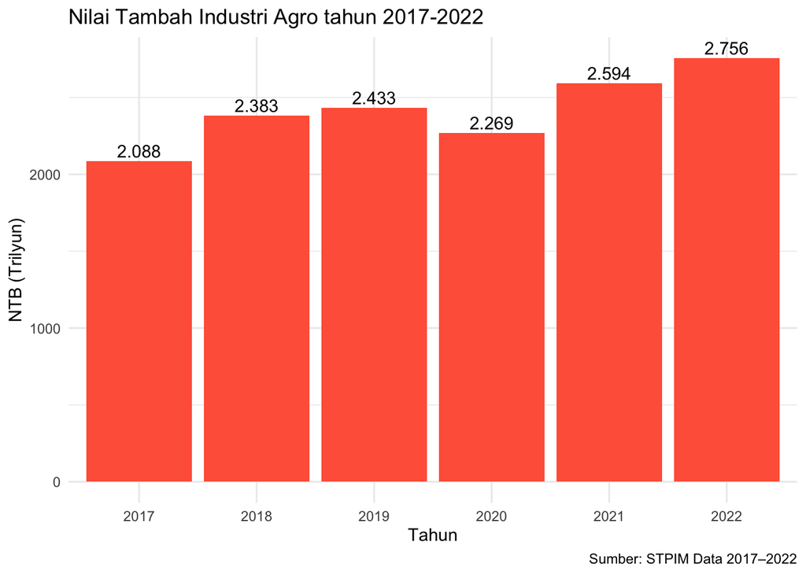